### Autores: Álvaro Huertas García, Guillermo García Hoyos

### Fecha: 15/02/2020

### Universidad Autónoma de Madrid - Máster en Bioinformática y Biología Computacional

# Notebook: Principal Component Analysis

In this notebook, we present the **Principal Component Analysis** algorithm and related applications such as data visualization or data compression.

## Contents

The structure of the notebook is as follows:

- Introducing Principal Component Analysis
- PCA as dimensionality reduction
- PCA for visualization: Wisconsin Diagnostic Breast Cancer Database
- Choosing the number of components
- Using PCA to find the perfect human

## Sources

*This notebook has been modified by Aythami Morales from:

i) the [Python Data Science Handbook](http://shop.oreilly.com/product/0636920034919.do) by Jake VanderPlas.*

ii) the BE/Bi 103 Data Analysis in the Biological Sciences [PCA tutorial](http://bebi103.caltech.edu.s3-website-us-east-1.amazonaws.com/2016/tutorials/aux4_pca.html) by Heidi Klumpe and Manuel Razo.

```python
%matplotlib inline
import numpy as np
import pandas as pd
import matplotlib.pyplot as plt
# seaborn is a package for statistical data visualization
import seaborn as sns; sns.set()
```

## 1. Introducing Principal Component Analysis

Principal component analysis (PCA) is a fast and flexible unsupervised method for dimensionality reduction in data. PCA is a statistical procedure that uses an orthogonal transformation to convert a set of observations of possibly correlated variables into a set of values of linearly uncorrelated variables called principal components. The number of distinct principal components is equal to the smaller of the number of original variables or the number of observations minus one. This transformation is defined in such a way that the first principal component has the largest possible variance (that is, accounts for as much of the variability in the data as possible), and each succeeding component in turn has the highest variance possible under the constraint that it is orthogonal to the preceding components. The resulting vectors are an uncorrelated orthogonal basis set. PCA is sensitive to the relative scaling of the original variables.

PCA is fundamentally a dimensionality reduction algorithm, but it can also be useful as a tool for visualization, for noise filtering, for feature extraction and engineering, and much more.

Its behavior is easiest to visualize by looking at a synthetic two-dimensional dataset. Consider the following 200 points:

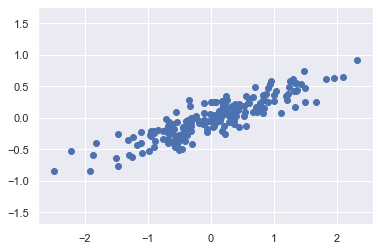

```python
# data.npy contains a synthetically generated two-dimensional data with 200 points
import os

dir_path = os.path.dirname(os.path.realpath("./data/data.npy"))
X=np.load(dir_path+'/data.npy')
# plot the 2 variables x0, x1
plt.scatter(X[:, 0], X[:, 1])
plt.axis('equal');
```

We can observe the different distribution of $x_{0}$ and $x_{1}$ in our data by its projections:

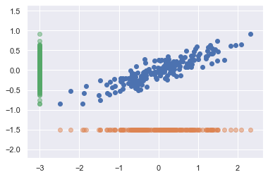

```python
# plot the 2 variables x0, x1
plt.scatter(X[:, 0], X[:, 1])
plt.axis('equal');
# plot the projections into horizontal and vertical axes (only visualization purpose)
plt.scatter(X[:, 0], -1.5*np.ones(len(X[:, 0])), alpha=0.5)
plt.scatter(-3*np.ones(len(X[:, 1])), X[:, 1], alpha=0.5)
```

By eye, it is clear that there is a nearly linear relationship between the $x_{0}$ and $x_{1}$ variables. The unsupervised learning problem attempts to learn about the *relationship* between the $x_{0}$ and $x_{1}$ values.

In principal component analysis, this relationship is quantified by finding a list of the *principal axes* in the data, and using those axes to describe the dataset. Using Scikit-Learn's `PCA` estimator, we can compute this as follows:

```python
# import PCA module from sklearn
from sklearn.decomposition import PCA
# define the PCA algorithm parameters, in this example only the number of components
pca = PCA(n_components=2)
# fit PCA algorithm to your data
pca.fit(X)
```

```
PCA(copy=True, iterated_power='auto', n_components=2, random_state=None,
    svd_solver='auto', tol=0.0, whiten=False)
```

The fit learns some quantities from the data, most importantly the "components", explained variance" and "explained variance ratio":

```python
print(pca.components_)
```

```
[[-0.94446029 -0.32862557]
 [-0.32862557  0.94446029]]
```

```python
print(pca.explained_variance_)
```

```
[0.7625315 0.0184779]
```

```python
print(pca.explained_variance_ratio_)
```

```
[0.97634101 0.02365899]
```

To see what these numbers mean, let's visualize them as vectors over the input data, using the "components" to define the direction of the vector, and the "explained variance" to define the squared-length of the vector:

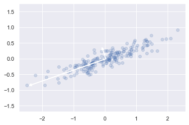

```python
#add your modules to the path
import sys
sys.path.append('./my_modules')

#my_module is an example of python module created to include your functions
import my_module

# plot data
plt.scatter(X[:, 0], X[:, 1], alpha=0.2)

# plot vectors to visualize the variance of the data
for length, vector in zip(pca.explained_variance_, pca.components_):
    v = vector * 3 * np.sqrt(length)
    my_module.draw_vector(pca.mean_, pca.mean_ + v)
plt.axis('equal');
```

These vectors represent the *principal axes* of the data, and the length of the vector is an indication of how "important" that axis is in describing the distribution of the data—more precisely, it is a measure of the variance of the data when projected onto that axis.

The projection of each data point onto the principal axes are the "principal components" of the data.

This transformation from data axes to principal axes is an *affine transformation*, which basically means it is composed of a translation, rotation, and uniform scaling.

While this algorithm to find principal components may seem like just a mathematical curiosity, it turns out to have very far-reaching applications in the world of machine learning and data exploration.

## 2. PCA as dimensionality reduction

Using PCA for dimensionality reduction involves zeroing out one or more of the smallest principal components, resulting in a lower-dimensional projection of the data that preserves the maximal data variance.

Here is an example of using PCA as a dimensionality reduction transform:

```python
# define the PCA parameters, only 1 component in this example
pca = PCA(n_components=1)
# fit PCA algorithm to your data
pca.fit(X)
# project the data according to the PCA components (1 component in this example)
X_pca = pca.transform(X)
print("original shape:   ", X.shape)
print("transformed shape:", X_pca.shape)
```

```
original shape:    (200, 2)
transformed shape: (200, 1)
```

The transformed data has been reduced to a single dimension. To understand the effect of this dimensionality reduction, we can perform the inverse transform of this reduced data and plot it along with the original data:

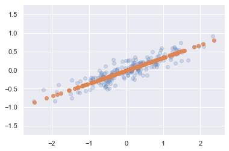

```python
# reconstruction of the data from the projection
X_new = pca.inverse_transform(X_pca)
# plot the original data
plt.scatter(X[:, 0], X[:, 1], alpha=0.2)
# plot the reconstructed data
plt.scatter(X_new[:, 0], X_new[:, 1], alpha=0.8)
plt.axis('equal');
```

The light points are the original data, while the dark points are the projected version. This makes clear what a PCA dimensionality reduction means: the information along the least important principal axis or axes is removed, leaving only the component(s) of the data with the highest variance. The fraction of variance that is cut out (proportional to the spread of points about the line formed in this figure) is roughly a measure of how much "information" is discarded in this reduction of dimensionality.

This reduced-dimension dataset is in some senses "good enough" to encode the most important relationships between the points: despite reducing the dimension of the data by 50%, the overall relationship between the data points are mostly preserved.

## 3. PCA for visualization: Wisconsin Diagnostic Breast Cancer Database

The usefulness of the dimensionality reduction may not be entirely apparent in only two dimensions, but becomes much more clear when looking at high-dimensional data.

To see this, let's take a quick look at the application of PCA to the 'Wisconsin Diagnostic Breast Cancer' from the UCI repository (https://archive.ics.uci.edu/ml/datasets/Breast+Cancer+Wisconsin+(Diagnostic)). The task of interest is to predict whether or not a cell corresponds to a malignant tumor. In this dataset all attributes (32 attributes) take real values. These include area, smoothness, perimeter, etc.

We start by loading the data:

```python
# read the data, 30 features for each record

dir_path = os.path.dirname(os.path.realpath("./data/wdbc.csv"))
data = pd.read_csv(dir_path+'/wdbc.csv',header=None) #as there is no header in this case
X = data.values[ :, 2:].astype(np.float)
# as a supervised problem, we have an associated label (benign, malign) to each sample on X
y = (data.values[ :, 1 ] == 'B').astype(np.int)
target_names = np.array([('benign'), ('malign')], dtype=np.dtype('U10'))

# make a DataFrame with a species column for the first 5 features. Note that the last element is not included in the selection
X5 = X[ :, 0:5].astype(np.float)
df_cancer = pd.DataFrame(X5)
df_cancer['target'] = target_names[y]

# take a look at df_cancer.
df_cancer.head(5)
```

|  | 0 | 1 | 2 | 3 | 4 | target |
| --- | --- | --- | --- | --- | --- | --- |
| 0 | 17.99 | 10.38 | 122.80 | 1001.0 | 0.11840 | benign |
| 1 | 20.57 | 17.77 | 132.90 | 1326.0 | 0.08474 | benign |
| 2 | 19.69 | 21.25 | 130.00 | 1203.0 | 0.10960 | benign |
| 3 | 11.42 | 20.38 | 77.58 | 386.1 | 0.14250 | benign |
| 4 | 20.29 | 14.34 | 135.10 | 1297.0 | 0.10030 | benign |

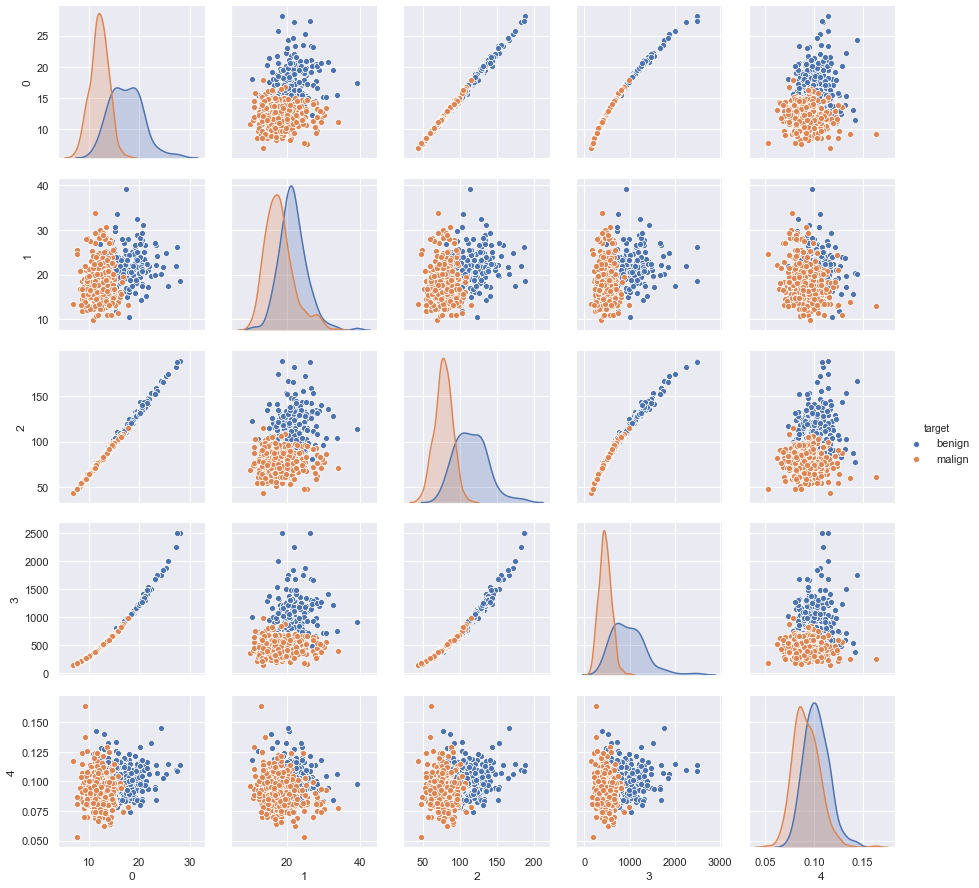

```python
# Plot pairwise comparison to explore the data
_ = sns.pairplot(df_cancer, hue='target')

plt.show()
```

Recall that the data consists of 569x32 matrix, meaning that they are 32-dimensional feature vectors from 569 samples. We ignore the first attribute in this dataset, which corresponds to the ID of each sample. Features are computed from a digitized image of a fine needle aspirate (FNA) of a breast mass. They describe characteristics of the cell nuclei present in the image.

To gain some intuition into the relationships between features, we can use PCA to project them to a more manageable number of dimensions, say two:

```python
# define the PCA parameters, 4 components in this example
pca = PCA(n_components=4)
# project from 30 to 4 dimensions according to the PCA components
X_r = pca.fit(X).transform(X)
print(X.shape)
print(X_r.shape)


print('explained variance ratio (first 4 components): %s'
      % str(pca.explained_variance_ratio_))
```

```
(569, 30)
(569, 4)
explained variance ratio (first 4 components): [9.82044672e-01 1.61764899e-02 1.55751075e-03 1.20931964e-04]
```

We can now plot the first two principal components of each point to learn about the data:

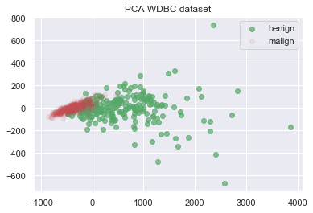

```python
plt.figure()
comp1=0; #first component to visualize, you can modify it
comp2=1; #second component to visualize, you can modify it

# plot the two components selected above for both malign and benign tumors
plt.scatter(X_r[y == 0, comp1], X_r[y == 0, comp2], color='g', alpha=.7, lw=1,
                label='benign')

plt.scatter(X_r[y == 1, comp1], X_r[y == 1, comp2], color='r', alpha=.1, lw=1,
                label='malign')

plt.legend(loc='best', shadow=False, scatterpoints=1)
plt.title('PCA WDBC dataset')

plt.show()
```

Recall what these components mean: the full data is a 30-dimensional point cloud, and these points are the projection of each data point along the directions with the largest variance.

Essentially, we have found the optimal stretch and rotation in 30-dimensional space that allows us to see the layout of the data in two dimensions.

## 4. Choosing the number of components

A vital part of using PCA in practice is the ability to estimate how many components are needed to describe the data. This can be determined by looking at the cumulative *explained variance ratio* as a function of the number of components:

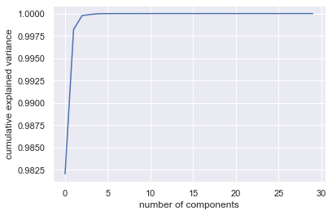

```python
# fit PCA algorithm to your data
pca = PCA().fit(X) #as we do not specify the number of components, it uses all, the 30
# plot the variance ratio according to the number of components
plt.plot(np.cumsum(pca.explained_variance_ratio_))
plt.xlabel('number of components')
plt.ylabel('cumulative explained variance');
```

This curve quantifies how much of the total, 30-dimensional variance is contained within the first $N$ components. For example, we see that with the WDBC dataset the first 2 components contain approximately 99% of the variance.

Here we see that our two-dimensional projection loses a reduced amount of information (as measured by the explained variance) and that we'd need only two features (in the transformed domain) to retain 99% of the variance. Looking at this plot for a high-dimensional dataset can help you understand the level of redundancy present in multiple observations.

## 5. Using PCA to find the perfect human

Genomes are hard to interpret. And so are PCA plots. Lior Pachter makes both these points in an interesting [blog post](https://liorpachter.wordpress.com/2014/12/02/the-perfect-human-is-puerto-rican/), where he calculates who the perfect human being would be according to their genomic SNP profile.

[SNPedia](http://www.snpedia.com/) is a database that contains a compilation of SNPs classified as *good* or *bad* according to some [GWAS](https://en.wikipedia.org/wiki/Genome-wide_association_study) criteria. Lior did the following:

1. He created a "perfect human" *in silico* by setting the alleles at all SNPs so that they are "good".
2. He then added the "perfect human" to a panel of genotyped individuals from across a variety of populations and performed **PCA** to reveal the location and population of origin of the individual that was closest to this hypothetical perfect human.

#### What is SNP?

Single nucleotide polymorphisms, frequently called SNPs (pronounced “snips”), are the most common type of genetic variation among people. Each SNP represents a difference in a single DNA building block, called a nucleotide.

We will use his data and repeat the analysis to find out who the perfect human being is and where is he/she from. You can download the SNP table, as well as information about the subjects here.

We will load it into a `DataFrame` where each column heading refers to a SNP and each row is a given subject. The index of the row is a string representing the subject (including `'perfect'`), and the column headings are the SNP IDs.

```python
# import the packages
import numpy as np
import pandas as pd
from sklearn.decomposition import PCA
import sklearn

# import matplotlib.pyplot as plt
import mpl_toolkits.mplot3d
import seaborn as sns

# read the SNP table
dir_path = os.path.dirname(os.path.realpath("./data/geno_table.txt"))
df_snp = pd.read_csv(dir_path+'/geno_table.txt', delimiter='\t',
                     index_col='snp_id').transpose()
df_snp.head() #this way we show some of the parts of the table
```

| snp_id | rs307377 | rs7366653 | rs41307846 | rs3753242 | rs35082957 | rs34154371 | rs35426403 | rs1143016 | rs3890745 | rs17472401 | ... | rs6007897 | rs9615362 | rs9627183 | rs28372448 | rs121913039 | rs121913037 | rs5770917 | rs6151429 | rs743616 | rs2071421 |
| --- | --- | --- | --- | --- | --- | --- | --- | --- | --- | --- | --- | --- | --- | --- | --- | --- | --- | --- | --- | --- | --- |
| perfect | 0 | 0 | 0 | 0 | 0 | 0 | 0 | 0 | 2 | 0 | ... | 0 | 0 | 0 | 0 | 0 | 0 | 0 | 0 | 0 | 0 |
| HG00096 | 2 | 0 | 1 | 0 | 0 | 0 | 0 | 0 | 1 | 0 | ... | 0 | 0 | 0 | 0 | 0 | 0 | 0 | 0 | 1 | 0 |
| HG00097 | 2 | 0 | 0 | 0 | 0 | 0 | 0 | 0 | 1 | 0 | ... | 0 | 0 | 0 | 0 | 0 | 0 | 0 | 0 | 2 | 0 |
| HG00099 | 2 | 0 | 0 | 0 | 0 | 0 | 0 | 0 | 1 | 0 | ... | 0 | 0 | 0 | 0 | 0 | 0 | 0 | 0 | 1 | 0 |
| HG00100 | 2 | 0 | 0 | 0 | 0 | 0 | 0 | 0 | 1 | 0 | ... | 0 | 0 | 1 | 0 | 0 | 0 | 0 | 0 | 1 | 0 |

5 rows × 4967 columns

Because we will do PCA with these data, they should be floating point numbers instead of integers.

We also have data about each individual, such as where they are from. The integrated_call_samples_v3.20130502.ALL.panel file is also included in the ZIP file containing the data.

```python
# convert the dato to type float
df_snp = df_snp.astype(np.float)

# Read the description of each individual
dir_path = os.path.dirname(os.path.realpath("./data/integrated_call_samples_v3.20130502.ALL.panel"))

fname = dir_path+'/integrated_call_samples_v3.20130502.ALL.panel'
df_info = pd.read_csv(fname, delimiter='\t',
                      index_col=0).dropna(axis=1, how='all')
df_info.head()
```

| sample | pop | super_pop | gender |
| --- | --- | --- | --- |
| HG00096 | GBR | EUR | male |
| HG00097 | GBR | EUR | female |
| HG00099 | GBR | EUR | female |
| HG00100 | GBR | EUR | female |
| HG00101 | GBR | EUR | male |

For convenience, we'll add this information to the SNP DataFrame.

```python
# add to the SNP dataframe the information about gender and super_pop
aux_cols = ['pop', 'super_pop', 'gender']
df_snp[aux_cols] = df_info

# change the super_pop column for the perfect human being
df_snp.loc['perfect', ['pop', 'super_pop']] = ['Perfect Human']*2

# take a look at auxiliary columns
df_snp[aux_cols].head()
```

| snp_id | pop | super_pop | gender |
| --- | --- | --- | --- |
| perfect | Perfect Human | Perfect Human | NaN |
| HG00096 | GBR | EUR | male |
| HG00097 | GBR | EUR | female |
| HG00099 | GBR | EUR | female |
| HG00100 | GBR | EUR | female |

**A note about units:** the subspaces that you obtain from performing PCA are not scale invariant. This means that, for example, if your dataset contains things measured in nanometers and things measured in meters, or even worse things measuring completely unrelated things, the units in which your measurement is stored would affect the PCA analysis. The simplest way to avoid this issue is to form a "common set of units" by standardizing your values such that they all have a common mean and variance (usually set to be zero and one respectively). Though still a somewhat subjective choice, this ensures that variance in each dimension happen on roughly the same scale. Fortunately, as in almost every case, scikit-learn can do the job for us. We will simply use the StandardScaler class from the preprocessing module of scikit-learn to fix this.

```python
# standardize the data before performing PCA
# we use .drop to remove the gender, pop and super_pop columns to avoid errors.
df_snp_std = sklearn.preprocessing.StandardScaler().fit_transform(
                            df_snp.drop(aux_cols, axis=1))

# define the number of components
n_components=5
snp_pca = PCA(n_components=n_components)

# project the data into this new PCA space
snp_pca.fit(df_snp_std)
df_snp_pca = snp_pca.transform(df_snp_std)

# convert back to a nice tidy dataframe
df_snp_pca = pd.DataFrame(df_snp_pca,
                columns=['PC' + str(x) for x in range(1, n_components+1)],
                index=df_snp.index)

# add again the gender, pop, and super_pop columns
df_snp_pca[aux_cols] = df_snp[aux_cols]
df_snp_pca.head()
```

|  | PC1 | PC2 | PC3 | PC4 | PC5 | pop | super_pop | gender |
| --- | --- | --- | --- | --- | --- | --- | --- | --- |
| perfect | -2.221873 | -13.823952 | 193.949699 | 26.727360 | -2.304881 | Perfect Human | Perfect Human | NaN |
| HG00096 | -6.037516 | -15.947683 | 0.537056 | -3.400835 | -3.562601 | GBR | EUR | male |
| HG00097 | -6.310191 | -14.804931 | 1.027730 | -13.755967 | 4.559503 | GBR | EUR | female |
| HG00099 | -7.102287 | -15.820245 | 4.378602 | -4.128551 | -3.088492 | GBR | EUR | female |
| HG00100 | -6.006800 | -17.297061 | 0.383347 | -4.469932 | -2.635377 | GBR | EUR | female |

Great! Now, we know that plotting our multi-dimensional data in 2-D will give us an idea of which points are similar and dissimilar. So, if we believe genetic fitness is entirely determined by the absence and presence of universally good and bad SNPs, we may be interested in which humans are closest to the "perfect" human created by Lior Pachter. (Shortly after, we may offer our services to Hydra.) We will find this out by plotting all the SNP profiles in 2-D space.

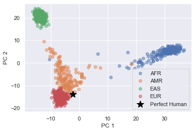

```python
# plot all populations except the perfect human
cols = ~df_snp_pca['super_pop'].isin(['Perfect Human'])
df_gb = df_snp_pca[cols].groupby(['super_pop'])
for key, group in df_gb:
    plt.plot(group.PC1, group.PC2, 'o', alpha=0.5, label=key)

# add the perfect human being to the plot
plt.plot(df_snp_pca.ix['perfect'].PC1, df_snp_pca.ix['perfect'].PC2, '*',
         markersize=15, color='black', label=df_snp_pca.ix['perfect'].super_pop)

# tidy the plot
plt.margins(0.05)
plt.legend(loc=0)
plt.xlabel('PC 1')
plt.ylabel('PC 2');
```

So the closest point to the perfect human being is patient HG00737 a **Puerto Rican woman!**

How confident are we that this plot indicates a Puerto Rican woman is the closest to being perfect? What if we considered additional axes?

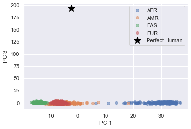

```python
# Plot all populations except the perfect human
cols = ~df_snp_pca['super_pop'].isin(['Perfect Human'])
df_gb = df_snp_pca[cols].groupby(['super_pop'])
for key, group in df_gb:
    plt.plot(group.PC1, group.PC3, 'o', alpha=0.5, label=key)

# Add the perfect human being to the plot
plt.plot(df_snp_pca.ix['perfect'].PC1, df_snp_pca.ix['perfect'].PC3, '*',
         markersize=15, color='black', label=df_snp_pca.ix['perfect'].super_pop)

# Tidy the plot.
plt.margins(0.05)
plt.legend(loc=0)
plt.xlabel('PC 1')
plt.ylabel('PC 3');
```

The perfect human is actually... not human. What happened here? We didn't check how much variance the first two axes explained; for the most part, we picked two dimensions because we publish papers in a two-dimensional format. It seems that there is a significant amount of variance explained by the third axis. In fact, it separates the "perfect" human from all other humans.

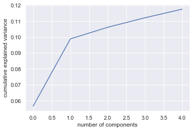

```python
# plot the variance ratio according to the number of components

plt.plot(np.cumsum(snp_pca.explained_variance_ratio_))
plt.xlabel('number of components')
plt.ylabel('cumulative explained variance');
```

It seems our plot explains less than 10% of the variation. A 2-D plot is vastly oversimplified. Looking at the 3-D plot, we see how we fooled ourselves.

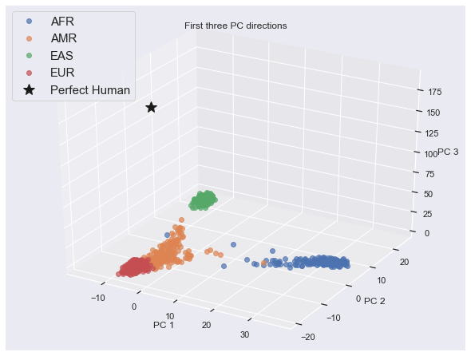

```python
# plot in 3D with the first 3 PCA components
fig = plt.figure(1, figsize=(8, 6))
ax = mpl_toolkits.mplot3d.Axes3D(fig)
for key, group in df_snp_pca.groupby(['super_pop']):
    if key == 'Perfect Human':
        ax.plot(group.PC1, group.PC2, group.PC3, 'k*', markersize=15,
                label=key)
    else:
        ax.plot(group.PC1, group.PC2, group.PC3, 'o', alpha=0.7, label=key)

ax.set_title("First three PC directions")
ax.set_xlabel("PC 1")
ax.set_ylabel("PC 2")
ax.set_zlabel("PC 3")
ax.legend(loc='upper left', fontsize=15);
```

This is an important reminder that PCA removes some variance to help us focus on the largest (and presumably most important) variance. Here however, there was important information even in the "lower" order variation. By plotting in 2-D, we implicitly assumed that most of the structure of SNP variation is itself 2-D. Perhaps, for something very complex like genomes, we should expect many higher order interactions to be still be important to understanding the system.

A note on Pachter's analysis: This blog post ended up being fairly controversial because it is so easy to (mis)interpret the 2-D PCA plot. Lior's original intent was to show that James Watson's racist ideas of having a perfect human being were completely wrong. Instead, however, most people took the sarcastic title seriously. Eventually, scientists from Puerto Rico, who collected the samples, explained the actual results for the people that only read Lior's title.

## TASK: CREATE AN AUTOMATIC PROGRAM TO DEFINE THE NUMBER OF COMPONENTS NECCESSARY TO RETAIN 99% OF VARIANCE ON SNPedia DATABASE

### Autores: Álvaro Huertas García, Guillermo García Hoyos

### Fecha: 15/02/2020

- En primer lugar cargamos los datos que pretendemos reducir con la PCA.
- El siguiente paso consiste en normalizar los datos de partida para que sea posible la comparación de los diferentes componentes y la selección de los componentes que explican mayor varianza de nuestros datos sea correcta.
- A continuación, ajustamos el algoritmo PCA a nuestros datos. En este paso es importante señalar que como nuestra intención es conocer qué número de componentes son necesarios para poder explicar (retener) el 99% de la varianza de nuestros datos, vamos a ajustar el algoritmo PCA con el número máximo de componentes posibles. En nuestro caso, el número de características iniciales (4967) es mayor que el número de muestras (1093). Como se indica en la documentacion [[1]](https://scikit-learn.org/stable/modules/generated/sklearn.decomposition.PCA.html), PCA cogerá como máximo número de componentes el mínimo entre el número de muestras (1093) y el número de componentes (4967). La explicación de este comportamiento se debe a que cada componente principal es la proyección de los datos en un vector propio de la matriz de covarianza de datos, por lo que, si tiene menos muestras (1093) que características (4967), la matriz de covarianza solo tendrá 1093 valores propios distintos de cero, es decir, con 1093 componentes explicaríamos el 100% de la varianza y el resto de componentes no retendrían nada de la varianza de nuestros datos. Por lo tanto, solo hay 1093 vectores propios, es decir, solo 1093 componentes que tienen sentido. De este modo, incluir más de 1093 características meterían ruido en el análisis [[2]](https://stackoverflow.com/questions/51040075/why-sklearn-pca-needs-more-samples-than-new-featuresn-components) [[3]](https://stats.stackexchange.com/questions/28909/pca-when-the-dimensionality-is-greater-than-the-number-of-samples).
- Una vez se ha ajustado la PCA a nuestros datos, procedemos a recuperar el porcentaje de varianza retenida por cada uno de los componentes incluidos en análisis. El cálculo del número de componentes necesarios para retener el 99% de la varianza se realiza mediante la suma acumulada de la varianza explicada de cada componente hasta que esta varianza acumulada sea superior a 0.99. Se han realizado dos métodos:
  1. El primero emplea la función *cumsum()* de numpy para realizar la suma acumulada de la varianza; el array obtenido se transforma en un array de booleanos con True para aquellos componentes menores de 0.99 y False para los superiores a 0.99, de modo que la suma del array interpreta los True como 1 y los False como 0. De este modo, el resultado de la suma se corresponde al número de componentes necesarios antes de explicar el 99% de la varianza. Finalmente se calcula el número de componentes necesarios para retener el 99% de la varianza sumándole 1 al resultado anterior. Este método se ha incorporado al documento *my_module.py* con su correspondiente docstring.
  2. El método 2 emplea un bucle *while* donde se realiza la suma acumulada de la varianza a la vez que se lleva la cuenta del número de componentes necesarios (equivalente al número de iteraciones) hasta alcanzar el 99% de varianza acumulada.

```python
# Paso 1: Cargamos los datos
df_snp = pd.read_csv('./data/geno_table.txt', delimiter='\t',
                     index_col='snp_id').transpose()
df_snp.shape # 1093 filas (individuos) 4967 columnas (SNPs, features o componentes estudiados)


# Paso 2: Estandarizamos y normalizamos los datos antes de realizar PCA
df_snp_std = sklearn.preprocessing.StandardScaler().fit_transform(df_snp) # aquí está normalizado

# Paso 3: Ajustamos el algoritmo PCA a nuestros datos
# n_components = min(df_snp.shape) Es como trabaja scikitlearn
snp_pca = PCA().fit(df_snp_std) # empleara todos los componentes dado que no especificamos el número
```

```python
# Método 1

# Calculamos el número inicial de componentes ha reducir
print("Número total de componentes:", df_snp_std.shape[0])

# Número de componentes que explican 99% de varianza
n_componentes = sum(np.cumsum(snp_pca.explained_variance_ratio_) < 0.99) + 1 # más uno porque hay que incluir el que supera el 0.99

if n_componentes == len(snp_pca.explained_variance_ratio_):
        varianza_expl = np.cumsum(snp_pca.explained_variance_ratio_)[len(pca_variance_ratio)-1]

else:
        varianza_expl = np.cumsum(snp_pca.explained_variance_ratio_)[n_componentes-1]


print("Número de componentes necesarias para explicar el 99% de la varianza:", n_componentes,
     "\nLa varianza que consigues explicar con estos componentes es:", varianza_expl)
```

```
Número total de componentes: 1093
Número de componentes necesarias para explicar el 99% de la varianza: 1041
La varianza que consigues explicar con estos componentes es: 0.9901765995147425
```

```python
# Método 2
print("Número total de componentes:", df_snp_std.shape[0])

# Número de componentes que explican 99% de varianza
n_components = 0
varianza_expl = 0
while varianza_expl < float(0.99):
    varianza_expl += float(snp_pca.explained_variance_ratio_[n_components])
    n_components += 1

print("Número de componentes necesarias para explicar el 99% de la varianza:", n_components,
     "\nLa varianza que consigues explicar con estos componentes es:", varianza_expl)
```

```
Número total de componentes: 1093
Número de componentes necesarias para explicar el 99% de la varianza: 1041
La varianza que consigues explicar con estos componentes es: 0.9901765995147425
```

**Incorporamos el método 1 como función en my_module.py**

```python
# Método 1 implementado en formato de función en my_module.py
import sys
sys.path.append('./my_modules')

#my_module is an example of python module created to include your functions
import my_module


pca.explained_variance_ratio_ = snp_pca.explained_variance_ratio_
var_expl_deseada = 0.99

n_comp, var = my_module.num_componentes(pca.explained_variance_ratio_, var_expl_deseada)
print("Número de componentes necesarias para explicar el 99% de la varianza:", n_comp,
       "\nLa varianza que consigues explicar con estos componentes es:", var)
```

```
Número de componentes necesarias para explicar el 99% de la varianza: 1041
La varianza que consigues explicar con estos componentes es: 0.9901765995147425
```

```python
# Pruebas de la función num_compnentes()
# Hay que tener en cuenta que la varianza total de los datos nunca será mayor ni menor que 1

print("Caso 1")
# Caso 1: Se requieren todos los componentes
pca.explained_variance_ratio_ = [0, 0, 0.02, 0.98] # Para el 99% requieres 4 componentes
n_comp, var = my_module.num_componentes(pca.explained_variance_ratio_, var_expl_deseada)
print("Número de componentes necesarias para explicar el 99% de la varianza:", n_comp,
       "\nLa varianza que consigues explicar con estos componentes es:", var)


print("\nCaso 2")
# Caso 2: Se requieren todos los componentes
pca.explained_variance_ratio_ = [0, 0, 0.00, 1] # Para el 99%  se requieren 4 componentes
n_comp, var = my_module.num_componentes(pca.explained_variance_ratio_, var_expl_deseada)
print("Número de componentes necesarias para explicar el 99% de la varianza:", n_comp,
       "\nLa varianza que consigues explicar con estos componentes es:", var)


print("\nCaso 3")
# Caso 3: Uno de los componentes aporta el exactamente el 99%
pca.explained_variance_ratio_ = [0, 0, 0.99, 0.01] # Para el 99%  se requieren 4 componentes
n_comp, var = my_module.num_componentes(pca.explained_variance_ratio_, var_expl_deseada)
print("Número de componentes necesarias para explicar el 99% de la varianza:", n_comp,
       "\nLa varianza que consigues explicar con estos componentes es:", var)
```

```
Caso 1
Número de componentes necesarias para explicar el 99% de la varianza: 4
La varianza que consigues explicar con estos componentes es: 1.0

Caso 2
Número de componentes necesarias para explicar el 99% de la varianza: 4
La varianza que consigues explicar con estos componentes es: 1.0

Caso 3
Número de componentes necesarias para explicar el 99% de la varianza: 3
La varianza que consigues explicar con estos componentes es: 0.99
```

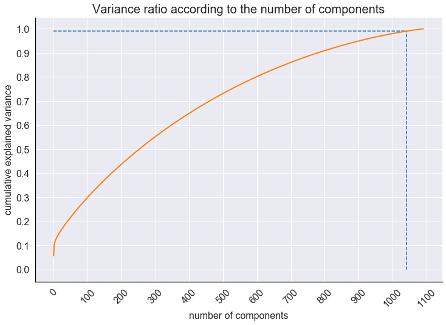

```python
# Visualización gráfica
# plot the variance ratio according to the number of components
fig, (ax) = plt.subplots(figsize = (12, 8))
plt.plot(np.cumsum(snp_pca.explained_variance_ratio_), c = "tab:orange", linewidth = 2)
plt.xlabel('number of components', fontsize = 16)
plt.ylabel('cumulative explained variance', fontsize = 16)
plt.title("Variance ratio according to the number of components", fontsize = 20);

# establecemos las etiquetas de los ejes x e y
xticks = np.arange(0, 1200, 100)
yticks = np.arange(0, 1.2, 0.1)
ax.set_xticks(xticks)
ax.set_yticks(yticks)
plt.xticks(rotation=45, fontsize = 16)
plt.yticks(fontsize = 16)
ax.tick_params( direction = 'out')

# ax.set_facecolor("white")

ax.spines['bottom'].set_color('black')
ax.spines['left'].set_color('black')

# mostramos el punto de corte de 0.99 de varianza
plt.hlines(y = 0.99, xmin = 0, xmax = 1041, linestyle = "dashed", color = "tab:blue")
plt.vlines(x = 1041, ymin = 0,  ymax = 0.99,  linestyle = "dashed", color = "tab:blue");
```

## Análisis

En lo que se refiere al análisis de nuestros resultados, observamos que la PCA ha conseguido reducir el número de dimensiones de 1093 a 1041 componentes. No obstante, la reducción conseguida es tan sólo de un 5% y esta reducción de la dimensionalidad sigue sin facilitar la visualización de los datos (principal objetivo de la PCA). Además, observamos que la varianza retenida crece de forma logarítmica con el número de SNPs incorporados en el estudio. Por ello las características estudiadas (SNPs), individualmente, retienen poca varianza de nuestros datos y emplear 2 o 3 componentes para poder visualizar nuestros datos sería un error dada la alta cantidad de información que se pierde al proyectar sobre estas componentes:

```python
retenida_2 = round(np.cumsum(snp_pca.explained_variance_ratio_)[2]*100, 2)
perdida_2 = round((1-np.cumsum(snp_pca.explained_variance_ratio_)[2])*100, 2)
retenida_3 = round(np.cumsum(snp_pca.explained_variance_ratio_)[3]*100)
perdida_3 = round((1-np.cumsum(snp_pca.explained_variance_ratio_)[3])*100)

print ("Varianza retenida con los 2 componentes principales: ", retenida_2)
print ("Varianza perdida con los 2 componentes principales: ", perdida_2 )
print()
print ("Varianza retenida con los 3 componentes principales: ", retenida_3 )
print ("Varianza perdida con los 3 componentes principales: ", perdida_3 )
```

```
Varianza retenida con los 2 componentes principales:  10.62
Varianza perdida con los 2 componentes principales:  89.38

Varianza retenida con los 3 componentes principales:  11.0
Varianza perdida con los 3 componentes principales:  89.0
```

Por todo esto, queda claro que no existe correlación entre los diferentes SNPs estudiados procedentes de la SNPedia DATABASE y que la PCA no ha conseguido realizar su principal objetivo. A pesar de ello, cabe destacar que aunque solo se hayan eliminado 52 SNPs y no sea suficiente la reducción de dimensiones para visualizar los datos, a nivel experimental en un laboratorio, reducir el estudio de validación de 52 SNPs sí puede ser una reducción sustancial de trabajo, de igual modo que el empleo de datos con menor dimensiones facilita el trabajo a otros algoritmos empleados para otros posibles análisis.